# Harsh Singal, OBAIS, University of Cincinnati (June 12, 2020)

# Lab-3

The objective of this lab is to get you started with regression model building, variable selection, and model evaluation in Python.

```python
import pandas as pd
import numpy as np
import sklearn
import matplotlib.pyplot as plt
import seaborn as sns
import warnings
warnings.filterwarnings("ignore")
```

# 1 Objective

We use Boston Housing Data as an illustrative example in this lab. We learn basic linear regression and analysis with Python. Code in this file is not the only correct way to do things, however it is important for you to understand what each statement does. You will have to modify the code accordingly for your homework.

# 2 Boston Housing Data

Boston housing data is a built-in dataset in sklearn datasets package, so you do not need to download externally. Package sklearn comes with Python when you installed Python, so no need to use "from sklearn import datasets" to download and install.

## 2.1 Load Data

```python
from sklearn import datasets

data = datasets.load_boston()
boston = pd.DataFrame(data.data, columns = map(str.lower, data.feature_names))
boston['medv'] = data.target
boston.head()
```

|  | crim | zn | indus | chas | nox | rm | age | dis | rad | tax | ptratio | b | lstat | medv |
| --- | --- | --- | --- | --- | --- | --- | --- | --- | --- | --- | --- | --- | --- | --- |
| 0 | 0.00632 | 18.0 | 2.31 | 0.0 | 0.538 | 6.575 | 65.2 | 4.0900 | 1.0 | 296.0 | 15.3 | 396.90 | 4.98 | 24.0 |
| 1 | 0.02731 | 0.0 | 7.07 | 0.0 | 0.469 | 6.421 | 78.9 | 4.9671 | 2.0 | 242.0 | 17.8 | 396.90 | 9.14 | 21.6 |
| 2 | 0.02729 | 0.0 | 7.07 | 0.0 | 0.469 | 7.185 | 61.1 | 4.9671 | 2.0 | 242.0 | 17.8 | 392.83 | 4.03 | 34.7 |
| 3 | 0.03237 | 0.0 | 2.18 | 0.0 | 0.458 | 6.998 | 45.8 | 6.0622 | 3.0 | 222.0 | 18.7 | 394.63 | 2.94 | 33.4 |
| 4 | 0.06905 | 0.0 | 2.18 | 0.0 | 0.458 | 7.147 | 54.2 | 6.0622 | 3.0 | 222.0 | 18.7 | 396.90 | 5.33 | 36.2 |

The original data are 506 observations on 14 variables, medv being the response variable y

```python
print(data.DESCR)
```

```
.. _boston_dataset:

Boston house prices dataset
---------------------------

**Data Set Characteristics:**

    :Number of Instances: 506

    :Number of Attributes: 13 numeric/categorical predictive. Median Value (attribute 14) is usually the target.

    :Attribute Information (in order):
        - CRIM     per capita crime rate by town
        - ZN       proportion of residential land zoned for lots over 25,000 sq.ft.
        - INDUS    proportion of non-retail business acres per town
        - CHAS     Charles River dummy variable (= 1 if tract bounds river; 0 otherwise)
        - NOX      nitric oxides concentration (parts per 10 million)
        - RM       average number of rooms per dwelling
        - AGE      proportion of owner-occupied units built prior to 1940
        - DIS      weighted distances to five Boston employment centres
        - RAD      index of accessibility to radial highways
        - TAX      full-value property-tax rate per $10,000
        - PTRATIO  pupil-teacher ratio by town
        - B        1000(Bk - 0.63)^2 where Bk is the proportion of blacks by town
        - LSTAT    % lower status of the population
        - MEDV     Median value of owner-occupied homes in $1000's

    :Missing Attribute Values: None

    :Creator: Harrison, D. and Rubinfeld, D.L.

This is a copy of UCI ML housing dataset.
https://archive.ics.uci.edu/ml/machine-learning-databases/housing/


This dataset was taken from the StatLib library which is maintained at Carnegie Mellon University.

The Boston house-price data of Harrison, D. and Rubinfeld, D.L. 'Hedonic
prices and the demand for clean air', J. Environ. Economics & Management,
vol.5, 81-102, 1978.   Used in Belsley, Kuh & Welsch, 'Regression diagnostics
...', Wiley, 1980.   N.B. Various transformations are used in the table on
pages 244-261 of the latter.

The Boston house-price data has been used in many machine learning papers that address regression
problems.

.. topic:: References

   - Belsley, Kuh & Welsch, 'Regression diagnostics: Identifying Influential Data and Sources of Collinearity', Wiley, 1980. 244-261.
   - Quinlan,R. (1993). Combining Instance-Based and Model-Based Learning. In Proceedings on the Tenth International Conference of Machine Learning, 236-243, University of Massachusetts, Amherst. Morgan Kaufmann.
```

## 2.2 EDA

We have introduced many EDA techniques in lab 2. We will briefly go through some of them here.

```python
boston.shape
```

```
(506, 14)
```

```python
boston.columns
```

```
Index(['crim', 'zn', 'indus', 'chas', 'nox', 'rm', 'age', 'dis', 'rad', 'tax',
       'ptratio', 'b', 'lstat', 'medv'],
      dtype='object')
```

```python
boston.dtypes
```

```
crim       float64
zn         float64
indus      float64
chas       float64
nox        float64
rm         float64
age        float64
dis        float64
rad        float64
tax        float64
ptratio    float64
b          float64
lstat      float64
medv       float64
dtype: object
```

```python
boston.describe()
```

|  | crim | zn | indus | chas | nox | rm | age | dis | rad | tax | ptratio | b | lstat | medv |
| --- | --- | --- | --- | --- | --- | --- | --- | --- | --- | --- | --- | --- | --- | --- |
| count | 506.000000 | 506.000000 | 506.000000 | 506.000000 | 506.000000 | 506.000000 | 506.000000 | 506.000000 | 506.000000 | 506.000000 | 506.000000 | 506.000000 | 506.000000 | 506.000000 |
| mean | 3.613524 | 11.363636 | 11.136779 | 0.069170 | 0.554695 | 6.284634 | 68.574901 | 3.795043 | 9.549407 | 408.237154 | 18.455534 | 356.674032 | 12.653063 | 22.532806 |
| std | 8.601545 | 23.322453 | 6.860353 | 0.253994 | 0.115878 | 0.702617 | 28.148861 | 2.105710 | 8.707259 | 168.537116 | 2.164946 | 91.294864 | 7.141062 | 9.197104 |
| min | 0.006320 | 0.000000 | 0.460000 | 0.000000 | 0.385000 | 3.561000 | 2.900000 | 1.129600 | 1.000000 | 187.000000 | 12.600000 | 0.320000 | 1.730000 | 5.000000 |
| 25% | 0.082045 | 0.000000 | 5.190000 | 0.000000 | 0.449000 | 5.885500 | 45.025000 | 2.100175 | 4.000000 | 279.000000 | 17.400000 | 375.377500 | 6.950000 | 17.025000 |
| 50% | 0.256510 | 0.000000 | 9.690000 | 0.000000 | 0.538000 | 6.208500 | 77.500000 | 3.207450 | 5.000000 | 330.000000 | 19.050000 | 391.440000 | 11.360000 | 21.200000 |
| 75% | 3.677083 | 12.500000 | 18.100000 | 0.000000 | 0.624000 | 6.623500 | 94.075000 | 5.188425 | 24.000000 | 666.000000 | 20.200000 | 396.225000 | 16.955000 | 25.000000 |
| max | 88.976200 | 100.000000 | 27.740000 | 1.000000 | 0.871000 | 8.780000 | 100.000000 | 12.126500 | 24.000000 | 711.000000 | 22.000000 | 396.900000 | 37.970000 | 50.000000 |

We skip the Exploratory Data Analysis (EDA) in this notes, but you should not omit it in your HW and Cases. EDA is very important and always the first analysis to do before any modeling.

# 2.3 Preparation

## 2.3.1 Splitting data to training and testing samples

Next we sample 90% of the original data and use it as the training set. The remaining 10% is used as test set. The regression model will be built on the training set and future performance of your model will be evaluated with the test set.

```python
from sklearn.model_selection import train_test_split
from random import sample
```

```python
#for statmodels smf function (explained in Model Building section)
num = list(range(len(boston)))
ran = sample(num, int(len(num)*0.9))
rem = [i for i in num if i not in ran]

boston_train = boston.iloc[ran, :]
boston_test = boston.iloc[rem, :]

#for sklearn LinearRegression function

X_train = boston_train.iloc[:,:-1]
y_train = boston_train.iloc[:,-1:]

X_test = boston_test.iloc[:,:-1]
y_test = boston_test.iloc[:,-1:]
```

### 2.3.2 (Optional) Standardization

If we want our results to be invariant to the units and the parameter estimates βi to be comparible, we can standardize the variables. Essentially we are replacing the original values with their z-score. For this we use StandardScaler function of sklearn

```python
from sklearn.preprocessing import StandardScaler
scaler = StandardScaler()
scaler.fit(boston)
pd.DataFrame(scaler.transform(boston), columns = boston.columns)
```

|  | crim | zn | indus | chas | nox | rm | age | dis | rad | tax | ptratio | b | lstat | medv |
| --- | --- | --- | --- | --- | --- | --- | --- | --- | --- | --- | --- | --- | --- | --- |
| 0 | -0.419782 | 0.284830 | -1.287909 | -0.272599 | -0.144217 | 0.413672 | -0.120013 | 0.140214 | -0.982843 | -0.666608 | -1.459000 | 0.441052 | -1.075562 | 0.159686 |
| 1 | -0.417339 | -0.487722 | -0.593381 | -0.272599 | -0.740262 | 0.194274 | 0.367166 | 0.557160 | -0.867883 | -0.987329 | -0.303094 | 0.441052 | -0.492439 | -0.101524 |
| 2 | -0.417342 | -0.487722 | -0.593381 | -0.272599 | -0.740262 | 1.282714 | -0.265812 | 0.557160 | -0.867883 | -0.987329 | -0.303094 | 0.396427 | -1.208727 | 1.324247 |
| 3 | -0.416750 | -0.487722 | -1.306878 | -0.272599 | -0.835284 | 1.016303 | -0.809889 | 1.077737 | -0.752922 | -1.106115 | 0.113032 | 0.416163 | -1.361517 | 1.182758 |
| 4 | -0.412482 | -0.487722 | -1.306878 | -0.272599 | -0.835284 | 1.228577 | -0.511180 | 1.077737 | -0.752922 | -1.106115 | 0.113032 | 0.441052 | -1.026501 | 1.487503 |
| ... | ... | ... | ... | ... | ... | ... | ... | ... | ... | ... | ... | ... | ... | ... |
| 501 | -0.413229 | -0.487722 | 0.115738 | -0.272599 | 0.158124 | 0.439316 | 0.018673 | -0.625796 | -0.982843 | -0.803212 | 1.176466 | 0.387217 | -0.418147 | -0.014454 |
| 502 | -0.415249 | -0.487722 | 0.115738 | -0.272599 | 0.158124 | -0.234548 | 0.288933 | -0.716639 | -0.982843 | -0.803212 | 1.176466 | 0.441052 | -0.500850 | -0.210362 |
| 503 | -0.413447 | -0.487722 | 0.115738 | -0.272599 | 0.158124 | 0.984960 | 0.797449 | -0.773684 | -0.982843 | -0.803212 | 1.176466 | 0.441052 | -0.983048 | 0.148802 |
| 504 | -0.407764 | -0.487722 | 0.115738 | -0.272599 | 0.158124 | 0.725672 | 0.736996 | -0.668437 | -0.982843 | -0.803212 | 1.176466 | 0.403225 | -0.865302 | -0.057989 |
| 505 | -0.415000 | -0.487722 | 0.115738 | -0.272599 | 0.158124 | -0.362767 | 0.434732 | -0.613246 | -0.982843 | -0.803212 | 1.176466 | 0.441052 | -0.669058 | -1.157248 |

506 rows × 14 columns

# 3 Model Building

In Python, there are many packages which can be used to generate linear regression function. But the main packages are sklearn LinearRegression function and statsmodel smf.ols function. Although sklearn's function is easy to use, it has one main disadvantage that it does not provide detailed model parameters values and summary for each variable. Therefore, we will use statsmodel function for model variables evaluation and sklearn function to find cross validation scores.

Your task is to build a best model with training data. You can refer to the sklearn/statsmodels function for more detailed description of linear regression.

The following model includes all x varables in the model

```python
import statsmodels.formula.api as smf
import statsmodels.api as sm

model_1 = smf.ols(formula='medv ~ crim + zn + indus + chas + nox + age + rm + dis + rad + tax + ptratio + b + lstat', data = boston_train).fit()
model_1.summary()
```

OLS Regression Results

| Dep. Variable: | medv | R-squared: | 0.744 |
| --- | --- | --- | --- |
| Model: | OLS | Adj. R-squared: | 0.737 |
| Method: | Least Squares | F-statistic: | 98.73 |
| Date: | Fri, 12 Jun 2020 | Prob (F-statistic): | 1.51e-121 |
| Time: | 17:13:47 | Log-Likelihood: | -1348.6 |
| No. Observations: | 455 | AIC: | 2725. |
| Df Residuals: | 441 | BIC: | 2783. |
| Df Model: | 13 |  |  |
| Covariance Type: | nonrobust |  |  |

|  | coef | std err | t | P>\|t\| | [0.025 | 0.975] |
| --- | --- | --- | --- | --- | --- | --- |
| Intercept | 33.7907 | 5.471 | 6.177 | 0.000 | 23.039 | 44.542 |
| crim | -0.1133 | 0.033 | -3.385 | 0.001 | -0.179 | -0.048 |
| zn | 0.0459 | 0.014 | 3.179 | 0.002 | 0.018 | 0.074 |
| indus | 0.0065 | 0.068 | 0.097 | 0.923 | -0.126 | 0.139 |
| chas | 1.9214 | 0.931 | 2.064 | 0.040 | 0.092 | 3.751 |
| nox | -16.1835 | 4.004 | -4.042 | 0.000 | -24.052 | -8.315 |
| age | -0.0054 | 0.014 | -0.388 | 0.698 | -0.033 | 0.022 |
| rm | 4.1128 | 0.448 | 9.185 | 0.000 | 3.233 | 4.993 |
| dis | -1.4937 | 0.210 | -7.110 | 0.000 | -1.907 | -1.081 |
| rad | 0.2810 | 0.069 | 4.053 | 0.000 | 0.145 | 0.417 |
| tax | -0.0124 | 0.004 | -3.119 | 0.002 | -0.020 | -0.005 |
| ptratio | -0.9252 | 0.138 | -6.710 | 0.000 | -1.196 | -0.654 |
| b | 0.0092 | 0.003 | 3.239 | 0.001 | 0.004 | 0.015 |
| lstat | -0.5002 | 0.055 | -9.124 | 0.000 | -0.608 | -0.392 |

| Omnibus: | 180.509 | Durbin-Watson: | 1.932 |
| --- | --- | --- | --- |
| Prob(Omnibus): | 0.000 | Jarque-Bera (JB): | 972.322 |
| Skew: | 1.642 | Prob(JB): | 7.29e-212 |
| Kurtosis: | 9.364 | Cond. No. | 1.52e+04 |

Warnings:  
[1] Standard Errors assume that the covariance matrix of the errors is correctly specified.  
[2] The condition number is large, 1.52e+04. This might indicate that there are  
strong multicollinearity or other numerical problems.

But, is this the model you want to use?

## 3.1 (Optional) Interaction terms in model

If you suspect the effect of one predictor x1 on the response y depends on the value of another predictor x2, you can add interaction terms in model. To specify interaction in the model, you put : between two variables with interaction effect. For example

```python
model_2 = smf.ols(formula='medv ~ crim : zn - 1', data=boston_train).fit()

#The following way automatically add the main effects of crim and zn
model_2 = smf.ols(formula='medv ~ crim * zn - 1', data=boston_train).fit()

model_2.summary()
```

OLS Regression Results

| Dep. Variable: | medv | R-squared (uncentered): | 0.391 |
| --- | --- | --- | --- |
| Model: | OLS | Adj. R-squared (uncentered): | 0.387 |
| Method: | Least Squares | F-statistic: | 96.70 |
| Date: | Fri, 12 Jun 2020 | Prob (F-statistic): | 2.31e-48 |
| Time: | 17:13:48 | Log-Likelihood: | -1989.0 |
| No. Observations: | 455 | AIC: | 3984. |
| Df Residuals: | 452 | BIC: | 3996. |
| Df Model: | 3 |  |  |
| Covariance Type: | nonrobust |  |  |

|  | coef | std err | t | P>\|t\| | [0.025 | 0.975] |
| --- | --- | --- | --- | --- | --- | --- |
| crim | 0.5288 | 0.095 | 5.593 | 0.000 | 0.343 | 0.715 |
| zn | 0.3684 | 0.040 | 9.322 | 0.000 | 0.291 | 0.446 |
| crim:zn | 2.4945 | 0.412 | 6.050 | 0.000 | 1.684 | 3.305 |

| Omnibus: | 22.508 | Durbin-Watson: | 1.001 |
| --- | --- | --- | --- |
| Prob(Omnibus): | 0.000 | Jarque-Bera (JB): | 39.203 |
| Skew: | -0.329 | Prob(JB): | 3.07e-09 |
| Kurtosis: | 4.279 | Cond. No. | 12.4 |

Warnings:  
[1] Standard Errors assume that the covariance matrix of the errors is correctly specified.

For now we will not investigate the interactions of variables.

# 4 Model Assessment

Suppose that everything in model diagnostics is okay. In other words, the model we have built is fairly a valid model. Then we need to evaluate the model performance in terms of different metrics.

Commonly used metrics include MSE, (adjusted) R2, AIC, BIC for in-sample performance, and MSPE for out-of-sample performance.

## 4.1 In-sample model evaluation (train error)

```python
pred = model_1.predict(boston_train)
pred
```

```
353    25.322078
195    41.213687
372    24.662872
151    18.293407
147     8.782599
         ...
389    13.763681
256    37.700685
178    31.551395
396    19.142229
168    26.211326
Length: 455, dtype: float64
```

```python
error = boston_train['medv'] - pred
MSE = (error*error).mean()
MSE
```

```
21.974889160503277
```

R^2 of the model

```python
model_1.rsquared
```

```
0.7442655485509322
```

Adjusted-R^2 of the model, if you add a variable (or several in a group), SSE will decrease, R^2 will increase, but Adjusted-R^2 could go either way.

```python
model_1.rsquared_adj
```

```
0.7367268912519801
```

AIC and BIC of the model, these are information criteria. Smaller values indicate better fit.

```python
model_1.aic
```

```
2725.1387470651393
```

```python
model_1.bic
```

```
2782.8229109304525
```

BIC, AIC, and Adjusted R^2 have complexity penalty in the definition, thus when comparing across different models they are better indicators on how well the model will perform on future data.

## 4.2 Out-of-sample prediction (test error)

To evaluate how the model performs on future data, we use predict() to get the predicted values from the test set.

```python
#pi is a vector that contains predicted values for test set.
pi = model_1.predict(boston_test)
test_error = boston_test['medv'] - pi
test_MSE = (test_error*test_error).mean()
test_MSE
```

```
22.268845152415754
```

A less popular measure is the Mean Absolute Error (MAE). You can probably guess that here instead of taking the average of squared error, MAE is the average of absolute value of error.

```python
test_MAE = test_error.abs().mean()
test_MAE
```

```
2.9468392010617586
```

## 4.3 Cross-validation

Instead of fitting a model on a pre-specified 90% training sample and evaluate the MSPE on the hold-out 10% testing sample, it is more reliable to use cross-validation for out-of-sample performance evaluation. For k-fold cross-validation, the dataset is divided into k parts (equal sample size). Each part serves as the testing sample in and the rest (k-1 together) serves as training sample. This training/testing procedure is iteratively performed k times. The CV score is usually the average of the metric of out-of-sample performance across k iterations.

```python
from sklearn.linear_model import LinearRegression
from sklearn.model_selection import cross_val_score
from sklearn.metrics import mean_squared_error
from sklearn.metrics import make_scorer
```

10-fold Cross Validation

```python
model_2 = LinearRegression()
cross_val_score(model_2, X_train, y_train, cv = 10).mean()
```

```
0.7024608733659885
```

Leave one out cross validation

```python
model_3 = LinearRegression()
mse = make_scorer(mean_squared_error)
cross_val_score(model_3, X_train, y_train, cv = X_train.shape[0], scoring = mse).mean()
```

```
24.06036116708959
```

Now we define a MAD cost function as the CV score. The function takes 2 input vectors, pi = predicted values, r = actual values.

```python
def MAD_cost(pi, r):
    return((abs(pi-r)).mean())


my_scorer = make_scorer(MAD_cost, greater_is_better=True)

model_4 = LinearRegression()
cross_val_score(model_3, X_train, y_train, scoring = my_scorer, cv = 10).mean()
```

```
3.449205820559224
```

# 5 Variable Selection

## 5.1 Best Subset Selection

```python
# Reference for more detailed analysis: https://xavierbourretsicotte.github.io/subset_selection.html

# Helper function for fitting linear regression (Sklearn)

def fit_linear_reg(X,Y):
    #Fit linear regression model and return RSS and R squared values
    model_k = LinearRegression(fit_intercept = True)
    model_k.fit(X,Y)
    RSS = mean_squared_error(Y, model_k.predict(X))*len(Y)
    R_squared = model_k.score(X,Y)
    return RSS, R_squared

#Implementing Best subset selection (using itertools.combinations)¶
#Importing tqdm for the progress bar
from tqdm import tnrange, tqdm_notebook
import itertools

#Initialization variables
Y = y_train['medv']
X = X_train
k = len(y_train.columns) + 1
RSS_list, R_squared_list, feature_list = [],[],[]
numb_features = []

#Looping over k features in X
for k in tnrange(1,len(X.columns) + 1, desc = 'Loop...'):

    #Looping over all possible combinations: from 11 choose k
    for combo in itertools.combinations(X.columns,k):
        tmp_result = fit_linear_reg(X[list(combo)],Y)   #Store temp result
        RSS_list.append(tmp_result[0])                  #Append lists
        R_squared_list.append(tmp_result[1])
        feature_list.append(combo)
        numb_features.append(len(combo))

#Store in DataFrame
df_f = pd.DataFrame({'numb_features': numb_features,'RSS': RSS_list,
                   'R_squared':R_squared_list,'features':feature_list})

#Finding the best subsets for each number of features
#Using the smallest RSS value, or the largest R_squared value

df_min = df_f[df_f.groupby('numb_features')['RSS'].transform(min) == df_f['RSS']]
df_max = df_f[df_f.groupby('numb_features')['R_squared'].transform(max) == df_f['R_squared']]
```

```python
display(df_max)
```

|  | numb_features | RSS | R_squared | features |
| --- | --- | --- | --- | --- |
| 12 | 1 | 18025.513741 | 0.538960 | (lstat,) |
| 69 | 2 | 13831.135013 | 0.646240 | (rm, lstat) |
| 340 | 3 | 12226.107832 | 0.687292 | (rm, ptratio, lstat) |
| 1056 | 4 | 11851.958139 | 0.696861 | (rm, ptratio, b, lstat) |
| 2276 | 5 | 11129.416114 | 0.715342 | (nox, rm, dis, ptratio, lstat) |
| 4040 | 6 | 10835.727227 | 0.722854 | (nox, rm, dis, ptratio, b, lstat) |
| 5720 | 7 | 10699.448456 | 0.726339 | (chas, nox, rm, dis, ptratio, b, lstat) |
| 6218 | 8 | 10548.253088 | 0.730206 | (crim, zn, nox, rm, dis, ptratio, b, lstat) |
| 7590 | 9 | 10336.553238 | 0.735621 | (crim, nox, rm, dis, rad, tax, ptratio, b, lstat) |
| 7975 | 10 | 10099.726617 | 0.741678 | (crim, zn, nox, rm, dis, rad, tax, ptratio, b,... |
| 8150 | 11 | 10002.185745 | 0.744173 | (crim, zn, chas, nox, rm, dis, rad, tax, ptrat... |
| 8187 | 12 | 9998.786602 | 0.744260 | (crim, zn, chas, nox, rm, age, dis, rad, tax, ... |
| 8190 | 13 | 9998.574568 | 0.744266 | (crim, zn, indus, chas, nox, rm, age, dis, rad... |

What is the problem with best subset regression? If there are n independent variables, the number of possible nonempty subsets is 2^n - 1. If you try a best subset regression with more than 50 variables, you might need to wait for your entire life to get the result.

## 5.2 Forward/Backward/Stepwise Regression

### 5.2.1 Forward Selection

```python
#importing the necessary libraries
#use pip install mlxtend if package not installed previously
from mlxtend.feature_selection import SequentialFeatureSelector as SFS
from mlxtend.plotting import plot_sequential_feature_selection as plot_sfs

# Sequential Forward Selection(sfs) using Rsquared values
sfs_forward = SFS(LinearRegression(), k_features=8, forward=True, floating=False, scoring = 'r2', cv = 0)

sfs_forward.fit(X_train, y_train)
sfs_forward.k_feature_names_
```

```
('zn', 'chas', 'nox', 'rm', 'dis', 'ptratio', 'b', 'lstat')
```

Here we are directly using the optimal value of k_features argument in forward selection. In order to find out the optimal number of significant features, we can use hit and trial method for different value of k_features and make the final decision by plotting it against the model performance.

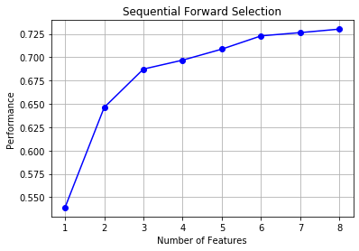

```python
fig1 = plot_sfs(sfs_forward.get_metric_dict(), kind='std_err')
plt.title('Sequential Forward Selection')
plt.grid()
plt.show()
```

```python
pd.DataFrame.from_dict(sfs_forward.get_metric_dict()).T
```

|  | feature_idx | cv_scores | avg_score | feature_names | ci_bound | std_dev | std_err |
| --- | --- | --- | --- | --- | --- | --- | --- |
| 1 | (12,) | [0.5389597949813458] | 0.53896 | (lstat,) | NaN | 0 | NaN |
| 2 | (5, 12) | [0.6462398013414685] | 0.64624 | (rm, lstat) | NaN | 0 | NaN |
| 3 | (5, 10, 12) | [0.6872917275887416] | 0.687292 | (rm, ptratio, lstat) | NaN | 0 | NaN |
| 4 | (5, 10, 11, 12) | [0.6968613883289538] | 0.696861 | (rm, ptratio, b, lstat) | NaN | 0 | NaN |
| 5 | (5, 7, 10, 11, 12) | [0.7086558413843063] | 0.708656 | (rm, dis, ptratio, b, lstat) | NaN | 0 | NaN |
| 6 | (4, 5, 7, 10, 11, 12) | [0.722853618826129] | 0.722854 | (nox, rm, dis, ptratio, b, lstat) | NaN | 0 | NaN |
| 7 | (3, 4, 5, 7, 10, 11, 12) | [0.7263392333460932] | 0.726339 | (chas, nox, rm, dis, ptratio, b, lstat) | NaN | 0 | NaN |
| 8 | (1, 3, 4, 5, 7, 10, 11, 12) | [0.7300836417490595] | 0.730084 | (zn, chas, nox, rm, dis, ptratio, b, lstat) | NaN | 0 | NaN |

```python
#Alternate function using AIC values

def forward_selection(data, target):

    initial_features = data.columns.tolist()
    best_features = []

    aic = sm.OLS(target, sm.add_constant(data[best_features])).fit().aic
    aic_values = [aic]

    while (len(initial_features) > 0):
        remaining_features = list(set(initial_features) - set(best_features))
        new_aic = pd.Series(index = remaining_features)

        for new_column in remaining_features:
            model = sm.OLS(target, sm.add_constant(data[best_features+[new_column]])).fit()
            new_aic[new_column] = model.aic
        min_aic = new_aic.min()

        if(min_aic < aic):
            aic = min_aic
            aic_values.append(aic)
            best_features.append(new_aic.idxmin())
        else:
            break

    final_AIC = sm.OLS(target, sm.add_constant(data[list(best_features)])).fit().aic

    return best_features, final_AIC

print('The variable coefficients provided by the model are:')
print(forward_selection(X_train, y_train)[0])
print('\nFinal AIC value for the model is:')
print(forward_selection(X_train, y_train)[1])
```

```
The variable coefficients provided by the model are:
['lstat', 'rm', 'ptratio', 'b', 'dis', 'nox', 'chas', 'zn', 'crim', 'rad', 'tax']

Final AIC value for the model is:
2721.303049386211
```

### 5.2.2 Backward Elimination

```python
# Sequential backward Selection(sfs)
sfs_backward = SFS(LinearRegression(), k_features=5, forward=False, floating=False, scoring = 'r2', cv = 0)

sfs_backward.fit(X_train, y_train)
sfs_backward.k_feature_names_
```

```
('nox', 'rm', 'dis', 'ptratio', 'lstat')
```

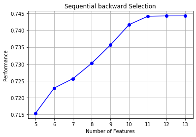

```python
fig2 = plot_sfs(sfs_backward.get_metric_dict(), kind=None)
plt.title('Sequential backward Selection')
plt.grid()
plt.show()
```

```python
pd.DataFrame.from_dict(sfs_backward.get_metric_dict()).T
```

|  | feature_idx | cv_scores | avg_score | feature_names | ci_bound | std_dev | std_err |
| --- | --- | --- | --- | --- | --- | --- | --- |
| 13 | (0, 1, 2, 3, 4, 5, 6, 7, 8, 9, 10, 11, 12) | [0.7442655485509323] | 0.744266 | (crim, zn, indus, chas, nox, rm, age, dis, rad... | NaN | 0 | NaN |
| 12 | (0, 1, 3, 4, 5, 6, 7, 8, 9, 10, 11, 12) | [0.744260125336609] | 0.74426 | (crim, zn, chas, nox, rm, age, dis, rad, tax, ... | NaN | 0 | NaN |
| 11 | (0, 1, 3, 4, 5, 7, 8, 9, 10, 11, 12) | [0.7441731851415789] | 0.744173 | (crim, zn, chas, nox, rm, dis, rad, tax, ptrat... | NaN | 0 | NaN |
| 10 | (0, 1, 4, 5, 7, 8, 9, 10, 11, 12) | [0.7416783733917762] | 0.741678 | (crim, zn, nox, rm, dis, rad, tax, ptratio, b,... | NaN | 0 | NaN |
| 9 | (0, 4, 5, 7, 8, 9, 10, 11, 12) | [0.7356210373596859] | 0.735621 | (crim, nox, rm, dis, rad, tax, ptratio, b, lstat) | NaN | 0 | NaN |
| 8 | (0, 4, 5, 7, 8, 10, 11, 12) | [0.7302012059431304] | 0.730201 | (crim, nox, rm, dis, rad, ptratio, b, lstat) | NaN | 0 | NaN |
| 7 | (0, 4, 5, 7, 10, 11, 12) | [0.7256349516247416] | 0.725635 | (crim, nox, rm, dis, ptratio, b, lstat) | NaN | 0 | NaN |
| 6 | (4, 5, 7, 10, 11, 12) | [0.722853618826129] | 0.722854 | (nox, rm, dis, ptratio, b, lstat) | NaN | 0 | NaN |
| 5 | (4, 5, 7, 10, 12) | [0.7153419114350426] | 0.715342 | (nox, rm, dis, ptratio, lstat) | NaN | 0 | NaN |

```python
#Alternate function using AIC values

def backward_elimination(data, target):

    best_features = data.columns.tolist()

    aic = sm.OLS(target, sm.add_constant(data[best_features])).fit().aic
    aic_values = [aic]

    while (True):
        new_aic = pd.Series(index = best_features)
        aic_diff = pd.Series(index = best_features)

        for new_column in best_features:
            model = sm.OLS(target, sm.add_constant(data[list(set(best_features) - set([new_column]))])).fit()
            new_aic[new_column] = model.aic
            aic_diff[new_column] = aic - model.aic

        max_aic = aic_diff.max()

        if(max_aic > 0):
            best_features.remove(aic_diff.idxmax())
            aic = new_aic[aic_diff.idxmax()]
            aic_values.append(aic)

        else:
            break

    final_AIC = sm.OLS(target, sm.add_constant(data[list(best_features)])).fit().aic

    return best_features, final_AIC

print('The variable coefficients provided by the model are:')
print(backward_elimination(X_train, y_train)[0])
print('\nFinal AIC value for the model is:')
print(backward_elimination(X_train, y_train)[1])
```

```
The variable coefficients provided by the model are:
['crim', 'zn', 'chas', 'nox', 'rm', 'dis', 'rad', 'tax', 'ptratio', 'b', 'lstat']

Final AIC value for the model is:
2721.303049386211
```

### 5.2.3 Bi-directional elimination(Stepwise Selection)

For stepwise selection, we put floating value in SFS function to be true.

```python
# Sequential Forward Floating Selection(sffs)
sffs = SFS(LinearRegression(), k_features=(3,11), forward=True, floating=True, cv=0)
sffs.fit(X_train, y_train)

sffs.k_feature_names_
```

```
('crim',
 'zn',
 'chas',
 'nox',
 'rm',
 'dis',
 'rad',
 'tax',
 'ptratio',
 'b',
 'lstat')
```

```python
pd.DataFrame.from_dict(sffs.get_metric_dict()).T
```

|  | feature_idx | cv_scores | avg_score | feature_names | ci_bound | std_dev | std_err |
| --- | --- | --- | --- | --- | --- | --- | --- |
| 1 | (12,) | [0.5389597949813458] | 0.53896 | (lstat,) | NaN | 0 | NaN |
| 2 | (5, 12) | [0.6462398013414685] | 0.64624 | (rm, lstat) | NaN | 0 | NaN |
| 3 | (5, 10, 12) | [0.6872917275887416] | 0.687292 | (rm, ptratio, lstat) | NaN | 0 | NaN |
| 4 | (5, 10, 11, 12) | [0.6968613883289538] | 0.696861 | (rm, ptratio, b, lstat) | NaN | 0 | NaN |
| 5 | (5, 7, 10, 11, 12) | [0.7086558413843063] | 0.708656 | (rm, dis, ptratio, b, lstat) | NaN | 0 | NaN |
| 6 | (4, 5, 7, 10, 11, 12) | [0.722853618826129] | 0.722854 | (nox, rm, dis, ptratio, b, lstat) | NaN | 0 | NaN |
| 7 | (3, 4, 5, 7, 10, 11, 12) | [0.7263392333460932] | 0.726339 | (chas, nox, rm, dis, ptratio, b, lstat) | NaN | 0 | NaN |
| 8 | (1, 3, 4, 5, 7, 10, 11, 12) | [0.7300836417490595] | 0.730084 | (zn, chas, nox, rm, dis, ptratio, b, lstat) | NaN | 0 | NaN |
| 9 | (0, 1, 3, 4, 5, 7, 10, 11, 12) | [0.7336504043133771] | 0.73365 | (crim, zn, chas, nox, rm, dis, ptratio, b, lstat) | NaN | 0 | NaN |
| 10 | (0, 1, 3, 4, 5, 7, 8, 10, 11, 12) | [0.7371446272409843] | 0.737145 | (crim, zn, chas, nox, rm, dis, rad, ptratio, b... | NaN | 0 | NaN |
| 11 | (0, 1, 3, 4, 5, 7, 8, 9, 10, 11, 12) | [0.7441731851415789] | 0.744173 | (crim, zn, chas, nox, rm, dis, rad, tax, ptrat... | NaN | 0 | NaN |

```python
#Alternate Function using p-values
def stepwise_selection(data, target, SL_in=0.01, SL_out = 0.05):

    initial_features = data.columns.tolist()
    best_features = []

    while (len(initial_features) > 0):
        remaining_features = list(set(initial_features) - set(best_features))
        new_pval = pd.Series(index = remaining_features)

        for new_column in remaining_features:
            model = sm.OLS(target, sm.add_constant(data[best_features+[new_column]])).fit()
            new_pval[new_column] = model.pvalues[new_column]
        min_p_value = new_pval.min()

        if(min_p_value < SL_in):
            best_features.append(new_pval.idxmin())

            while(len(best_features) > 0):
                best_features_with_constant = sm.add_constant(data[best_features])
                p_values = sm.OLS(target, best_features_with_constant).fit().pvalues[1:]
                max_p_value = p_values.max()
                if(max_p_value >= SL_out):
                    excluded_feature = p_values.idxmax()
                    best_features.remove(excluded_feature)
                else:
                    break
        else:
            break
    return best_features

stepwise_selection(X_train, y_train)
```

```
['lstat', 'rm', 'ptratio', 'b', 'dis', 'nox']
```

```python
#Alternate Function using the AIC values
def stepwise_selection(data, target):

    initial_features = data.columns.tolist()
    best_features = []

    aic = sm.OLS(target, sm.add_constant(data[best_features])).fit().aic

    while (len(initial_features) > 0):
        remaining_features = list(set(initial_features) - set(best_features))
        forw_aic = pd.Series(index = remaining_features)

        for new_column in remaining_features:
            model = sm.OLS(target, sm.add_constant(data[best_features+[new_column]])).fit()
            forw_aic[new_column] = model.aic
        min_aic = forw_aic.min()

        if(min_aic < aic):
            aic = min_aic
            best_features.append(forw_aic.idxmin())

            while (True):

                aic = sm.OLS(target, sm.add_constant(data[best_features])).fit().aic

                back_aic = pd.Series(index = best_features)
                aic_diff = pd.Series(index = best_features)

                for new_column in best_features:
                    model = sm.OLS(target, sm.add_constant(data[list(set(best_features) - set([new_column]))])).fit()
                    back_aic[new_column] = model.aic
                    aic_diff[new_column] = aic - model.aic

                max_aic = aic_diff.max()

                if(max_aic > 0):
                    best_features.remove(aic_diff.idxmax())
                    aic = back_aic[aic_diff.idxmax()]
                else:
                    break

        else:
            break

    final_AIC = sm.OLS(target, sm.add_constant(data[list(best_features)])).fit().aic

    return best_features, final_AIC

print('The variable coefficients provided by the model are:')
print(stepwise_selection(X_train, y_train)[0])
print('\nFinal AIC value for the model is:')
print(stepwise_selection(X_train, y_train)[1])
```

```
The variable coefficients provided by the model are:
['lstat', 'rm', 'ptratio', 'b', 'dis', 'nox', 'chas', 'zn', 'crim', 'rad', 'tax']

Final AIC value for the model is:
2721.303049386211
```

## 5.3 Feature Selection (Lasso Regression)

```python
from sklearn.linear_model import Lasso

#alpha = 1
model_lasso = Lasso(alpha = 1).fit(X_train, y_train['medv'])

print('The variable coefficients provided by the lasso are:')
coef = pd.Series(model_lasso.coef_, index = X_train.columns)
coef
```

```
The variable coefficients provided by the lasso are:
```

```
crim      -0.071245
zn         0.049490
indus     -0.002421
chas       0.000000
nox       -0.000000
rm         1.313552
age        0.015151
dis       -0.721779
rad        0.254300
tax       -0.015655
ptratio   -0.694259
b          0.008109
lstat     -0.731126
dtype: float64
```

```python
#alpha = 0.5
model_lasso = Lasso(alpha = 0.5).fit(X_train, y_train['medv'])

print('The variable coefficients provided by the lasso are:')
coef = pd.Series(model_lasso.coef_, index = X_train.columns)
coef
```

```
The variable coefficients provided by the lasso are:
```

```
crim      -0.091064
zn         0.048882
indus     -0.027952
chas       0.000000
nox       -0.000000
rm         2.825326
age       -0.000000
dis       -0.978733
rad        0.255750
tax       -0.015012
ptratio   -0.723157
b          0.009156
lstat     -0.626614
dtype: float64
```

```python
alpha_values = np.arange(0.01, 10, 0.01)
```

```python
#use 5-fold cross validation to pick lambda

from sklearn.linear_model import LassoCV

model_lassocv = LassoCV(cv = 5).fit(X_train, y_train['medv'])

print('The variable coefficients provided by the lasso are:')
coef = pd.Series(model_lassocv.coef_, index = X_train.columns)
coef
```

```
The variable coefficients provided by the lasso are:
```

```
crim      -0.081589
zn         0.049017
indus     -0.015232
chas       0.000000
nox       -0.000000
rm         2.107145
age        0.006260
dis       -0.861134
rad        0.254949
tax       -0.015311
ptratio   -0.709550
b          0.008667
lstat     -0.675166
dtype: float64
```

```python
print("LassoCV picked " + str(sum(coef != 0)) + " variables and eliminated the other " +  str(sum(coef == 0)) + " variables")
```

```
LassoCV picked 11 variables and eliminated the other 2 variables
```

```python
print("The chosen alpha is: ")
model_lassocv.alpha_
```

```
The chosen alpha is:
```

```
0.7398108030431108
```

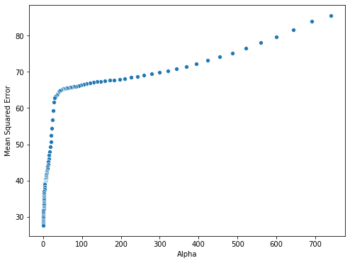

```python
mse_path = model_lassocv.mse_path_.mean(axis = 1)
aplha_path = model_lassocv.alphas_

plt.figure(figsize = (8,6))
sns.scatterplot(aplha_path, mse_path)
plt.ylabel('Mean Squared Error')
plt.xlabel('Alpha')
plt.show()
```

```python
print("Chosen model's R Squared: ")
model_lassocv.score(X_train, y_train)
```

```
Chosen model's R Squared:
```

```
0.7105312161995846
```

```python
test_pred = model_lassocv.predict(X_test)
test_error = y_test['medv'] - test_pred
test_MSE = (test_error*test_error).mean()
test_MSE
```

```
23.828387031123004
```

# 6 Diagnostic Plots

The diagnostic plots are not as important when regression is used in predictive (supervised) data mining as when it is used in economics. However it is still good to know:

- What the diagnostic plots should look like when no assumption is violated?
- If there is something wrong, what assumptions are possibly violated?
- What implications does it have on the analysis?
- (How) can I fix it?

## 6.1 Residual Plot

```python
base_model = LinearRegression()
base_model.fit(X_train, y_train)

pred = base_model.predict(X_train)
```

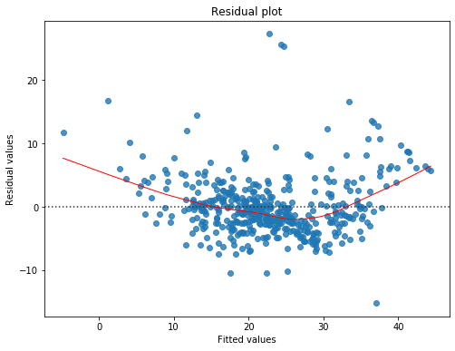

```python
plt.figure(figsize = (8,6))
sns.residplot(pred.reshape(-1), y_train['medv'], lowess=True, line_kws={'color': 'red', 'lw': 1, 'alpha': 1})
plt.xlabel("Fitted values")
plt.ylabel("Residual values")
plt.title('Residual plot')
plt.show()
```

## 6.2 QQ Plot

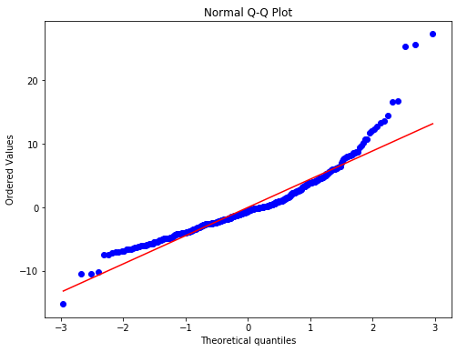

```python
from scipy import stats
residuals = y_train['medv'] - pred.reshape(-1)

plt.figure(figsize=(8,6))
stats.probplot(residuals, dist="norm", plot=plt)
plt.title("Normal Q-Q Plot")
plt.show()
```

## 6.3 Scale-Location plot

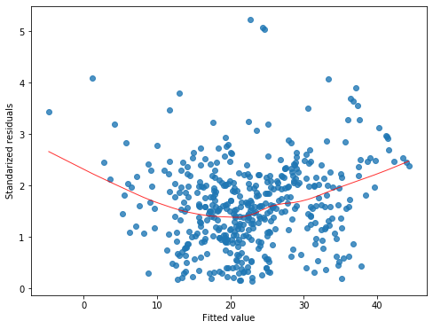

```python
model_norm_residuals_abs_sqrt=np.sqrt(np.abs(residuals))

plt.figure(figsize=(8,6))
sns.regplot(pred.reshape(-1), model_norm_residuals_abs_sqrt, scatter=True, lowess=True,
            line_kws={'color': 'red', 'lw': 1, 'alpha': 0.8})
plt.ylabel("Standarized residuals")
plt.xlabel("Fitted value")
plt.show()
```